# Medidas de tendencia central

[Nayeli Peña Peña](https://nayelipe.github.io)

Estadística 2022-2, [Facultad de economía](http://www.economia.unam.mx/)

2/3/2022

### 1. ¿Qué son las medidas de tendencia central? 🤔

> Definición: “Recogen un valor único, representativo de un conjunto de valores de una muestra, en ella se encuentra: media, mediana, moda, media aritmética, mediana armónica, media geométrica.”

[Universidad Santo Tomas 🌐](http://soda.ustadistancia.edu.co/enlinea/Segunda%20unidad%20Cuanti/mdidas_de_tendencia_central.html)

*Para este ejemplo, primero generaremos una serie de **100** números aleatorios entre **1** y **20** mediante la función `sample`. El argumento `TRUE` nos permitirá generar una muestra con remplazo:*

```r
numeros <- sample(1:20, 100, TRUE)
numeros
```

```
##   [1] 11 12  7 10 15 15 20 14  3 16  6 19  8 12 20  3 16 15  5  5 17 20 14  5  8
##  [26]  1  4 15 18  7  4  2  1 17 10 18 15  8  1  8 20 13  5  1  5  3  8 11 16  8
##  [51]  3  3  6  2 15  1 15 12 14 13 17 14  6  1 18 13 18 19  9 19 11 11  9  8  9
##  [76] 17 18  3 12 13  5  8 12  5 20 19 13 20  1 19  2 16  2  3 11  7  9  7 18  2
```

### 2. Mediana 📍

> Definición: “La **mediana** es el valor que ocupa el lugar central de todos los datos cuando éstos están ordenados de menor a mayor.

> La **mediana** se puede hallar solo para **variables cuantitativas**.”

[Superprof 📐](https://www.superprof.es/apuntes/escolar/matematicas/estadistica/descriptiva/mediana.html)

Para obtener la **mediana**, podemos ordenar los `numeros` de menor a mayor, **el número que esté en medio de la muestra será la mediana**. Si utilizamos R, se puede hacer el cálculo de la **mediana** con la función `median`:

```r
mediana <- median(numeros)
mediana
```

```
## [1] 11
```

### 3. Media 🧮

> Definición: “La Media (en símbolo M) es el cociente entre la suma de los datos y el número de datos.”

[Media aritmética 📌](https://www.uv.es/webgid/Descriptiva/24_media_aritmtica.html)

$$Media ={\frac {1}{n}}\sum _{i=1}^{n}a_{i}={\frac {a_{1}+a_{2}+\cdots +a_{n}}{n}}$$

Si usamos R, podemos obtener la media de una muestra si utlilizamos la función **mean**:

```r
media <- mean(numeros)
media
```

```
## [1] 10.43
```

### 4. Moda 📊

> Definición: “**se define como el número que está representado más veces dentro de esos datos**, es decir, aquel número que presenta una mayor frecuencia absoluta dentro de la muestra.”

[Mendoza, J. (2019)📗](https://estadisticamente.com/moda-estadistica/)

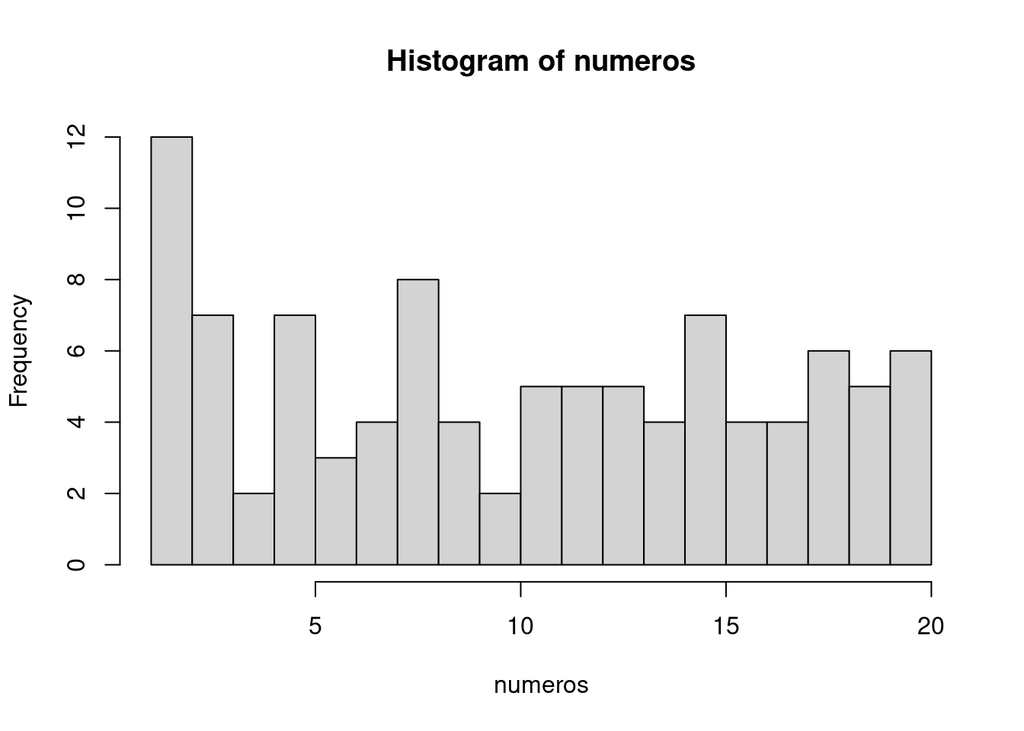

```r
# El argumento breaks nos permite dividir en histograma en las partes que queramos
hist(numeros, breaks = 20)
```

```r
tabla.frecuencias <- data.frame(table(numeros))
tabla.frecuencias
```

```
##    numeros Freq
## 1        1    7
## 2        2    5
## 3        3    7
## 4        4    2
## 5        5    7
## 6        6    3
## 7        7    4
## 8        8    8
## 9        9    4
## 10      10    2
## 11      11    5
## 12      12    5
## 13      13    5
## 14      14    4
## 15      15    7
## 16      16    4
## 17      17    4
## 18      18    6
## 19      19    5
## 20      20    6
```

### 5. Ejercicio 👩‍💻👨‍💻✍

Aplica lo que aprendiste, obten la **mediana**, **media** y **moda** de la siguiente muestra de números:

```r
# Con la función seq, creamos una secuencia de 1 a 10 en intervalos de 0.1 en 0.1
secuencia <- seq(1, 10, 0.1)
muestra <- sample(secuencia, 100, TRUE)
muestra
```

```
##   [1]  3.7  2.7  9.5  5.0  6.1  1.5  5.1  3.4  6.2  1.6  5.9  3.2  9.3  8.0  4.2
##  [16]  6.3  1.4  1.9  9.8  5.9  3.9  8.6  9.6  7.4  2.4  6.0  5.2  3.7  1.1  6.5
##  [31]  4.6  4.2  7.7  5.9  2.3  8.7 10.0  4.6  7.9  5.6  3.2  2.5 10.0  6.1  4.7
##  [46]  5.3  9.8  8.5  8.3  4.7  2.6  3.8  6.8  3.7  6.6  5.9  6.2  7.9  8.8  4.3
##  [61]  7.9  4.5  8.2  2.7  1.3  4.0  3.0  3.7  7.4  3.7  6.1  5.5  9.6  7.4  9.4
##  [76]  4.3  8.7  8.9  6.8  9.8  3.0  6.7  7.5  2.3  5.3  3.1  4.7  9.9  4.4  5.5
##  [91]  9.8  2.0  1.9  2.6  5.0  5.7  7.4  4.0  7.8  1.6
```

##### Mediana

```r
# Aquí el cálculo de la mediana
mediana.muestra <- median(muestra)
mediana.muestra
```

```
## [1] 5.5
```

##### Media

```r
# Aquí el cálculo de la media
media.muestra <- mean(muestra)
media.muestra
```

```
## [1] 5.594
```

##### Moda

```r
# Aquí el cálculo de la moda
tabla.moda <- data.frame(table(muestra))
tabla.moda
```

```
##    muestra Freq
## 1      1.1    1
## 2      1.3    1
## 3      1.4    1
## 4      1.5    1
## 5      1.6    2
## 6      1.9    2
## 7        2    1
## 8      2.3    2
## 9      2.4    1
## 10     2.5    1
## 11     2.6    2
## 12     2.7    2
## 13       3    2
## 14     3.1    1
```

[output cut: 48 more lines]

💻[Código disponible en RStudio Cloud](https://rstudio.cloud/project/3671022)💻